# Diabetes Data

JMC

2023-04-28

The following data is from a 652 patient cohort who received consecutive care for 5 years. Values are from time of diagnosis until five years after first diagnosis of diabetes.

# Demographics

| **Characteristic** | **Overall**, N = 652<sup>1</sup> | **Black**, N = 254<sup>1</sup> | **Hispanic**, N = 269<sup>1</sup> | **White**, N = 129<sup>1</sup> | **p-value**<sup>2</sup> | **N** |
| --- | --- | --- | --- | --- | --- | --- |
| Patient Characteristics |  |  |  |  |  |  |
| Sex |  |  |  |  | 0.013 |  |
| Female | 63% | 66% | 66% | 52% |  |  |
| Male | 37% | 34% | 34% | 48% |  |  |
| Age at Diagnosis | 51 (9) | 50 (8) | 51 (9) | 51 (10) | 0.045 |  |
| Year of Diagnosis | 2,011.32 (2.29) | 2,011.52 (2.36) | 2,011.50 (2.28) | 2,010.57 (2.05) | <0.001 |  |
| Avg A1c at Diagnosis | 7.18 (1.67) | 7.21 (1.81) | 7.20 (1.59) | 7.06 (1.57) | 0.6 |  |
| Change in A1c over 5 Years | -0.15 (1.86) | -0.15 (2.22) | -0.24 (1.65) | 0.05 (1.47) | 0.6 |  |
| Total A1c Values | 13.5 (4.9) | 13.4 (5.3) | 13.6 (4.6) | 13.6 (4.5) | 0.7 |  |
| Upstate Sites | 23% | 9.4% | 6.3% | 87% | <0.001 |  |
| Avg Office Visits Encounters | 107 (93) | 113 (105) | 97 (80) | 115 (93) | 0.2 |  |
| Avg Diabetes Encounters | 16 (45) | 18 (60) | 17 (34) | 11 (29) | <0.001 |  |
| Systolic BP | 128 (10) | 129 (11) | 126 (10) | 127 (9) | 0.047 |  |
| Diastolic BP | 79.6 (6.1) | 80.6 (6.4) | 78.6 (6.0) | 79.4 (5.3) | 0.002 |  |
| BMI | 39 (68) | 41 (81) | 38 (71) | 38 (9) | <0.001 |  |
| Unknown | 3 | 1 | 1 | 1 |  |  |
| Encounter Characteristics |  |  |  |  |  |  |
| newid | 337 (190) | 337 (201) | 353 (202) | 301 (123) |  | 8,817 |
| 1+ Diabetes Specific Encounter | 37% | 37% | 42% | 24% |  | 8,817 |
| Visits using Medicaid or Uninsured | 48% | 53% | 52% | 29% |  | 8,817 |
| A1c ≥ 8% | 19% | 20% | 17% | 21% |  | 8,817 |
| A1c ≥ 9% | 11% | 13% | 8.8% | 12% |  | 8,817 |

<sup>1</sup> %; Mean (SD)  
<sup>2</sup> Pearson’s Chi-squared test; Kruskal-Wallis rank sum test

# Graphs

[figure not shown]

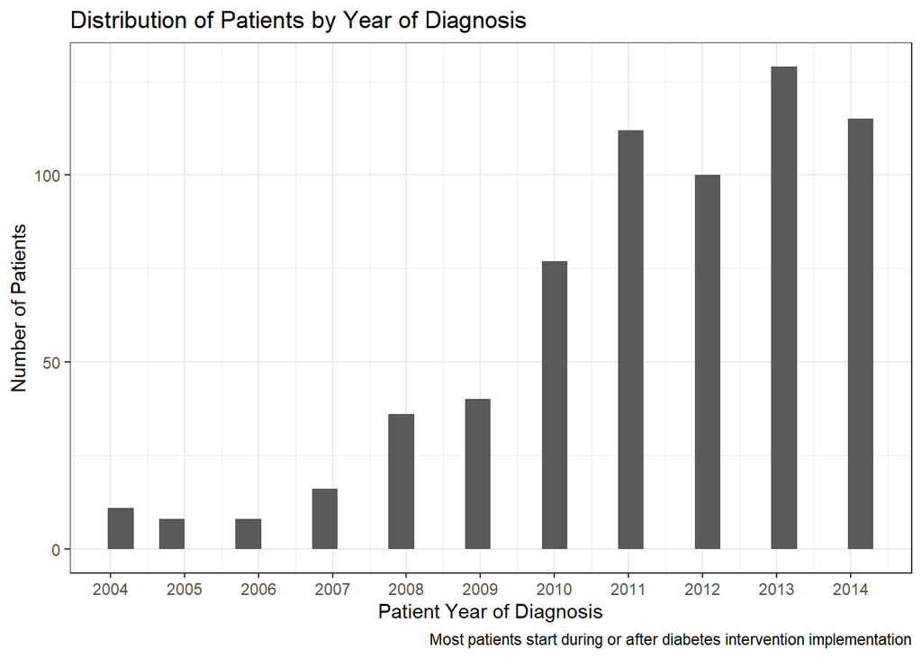

[figure not shown]

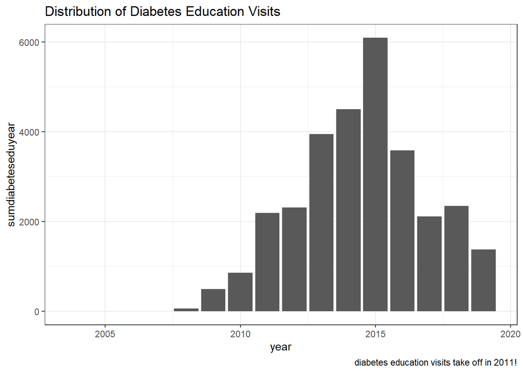

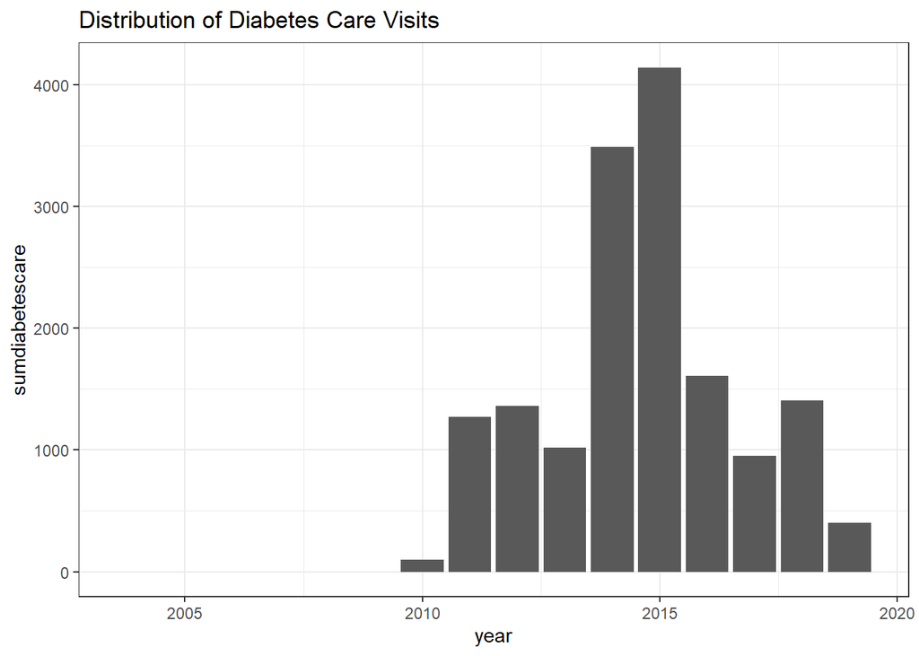

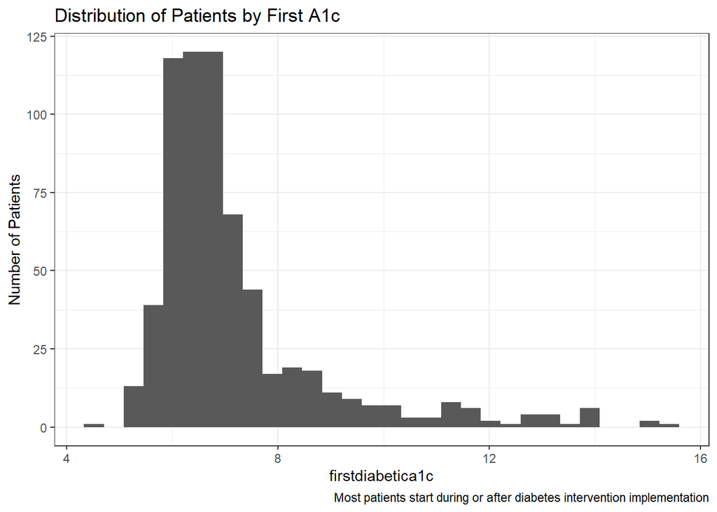

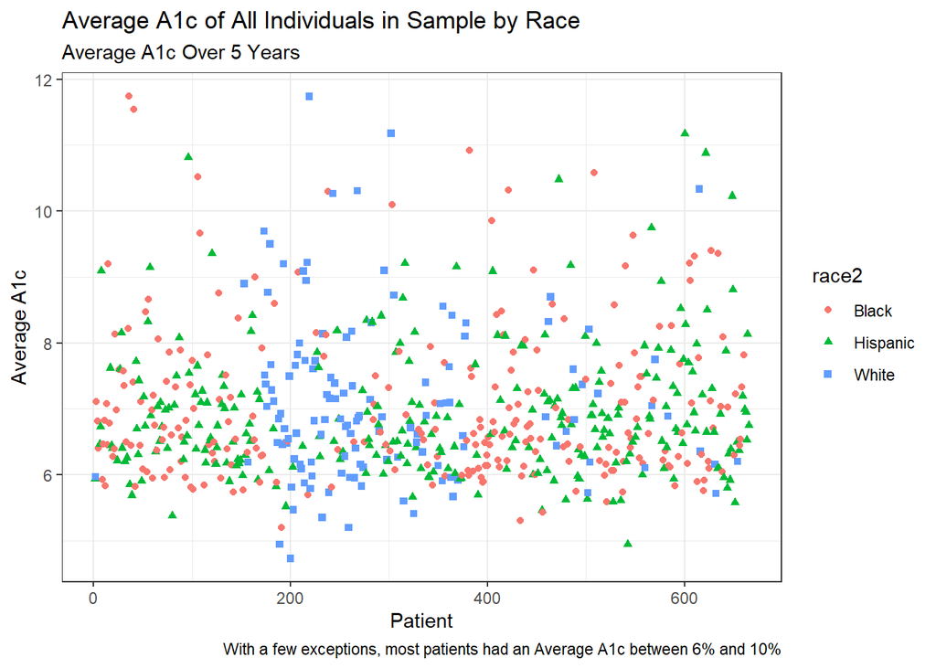

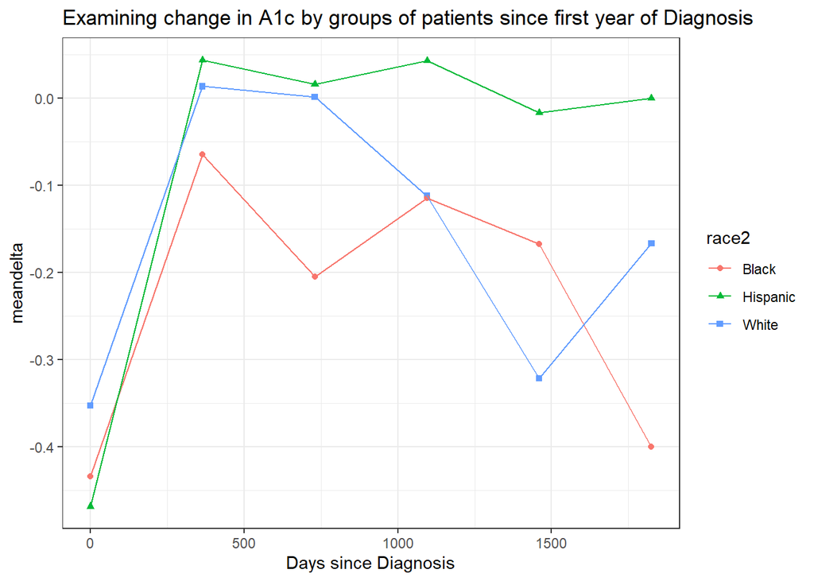

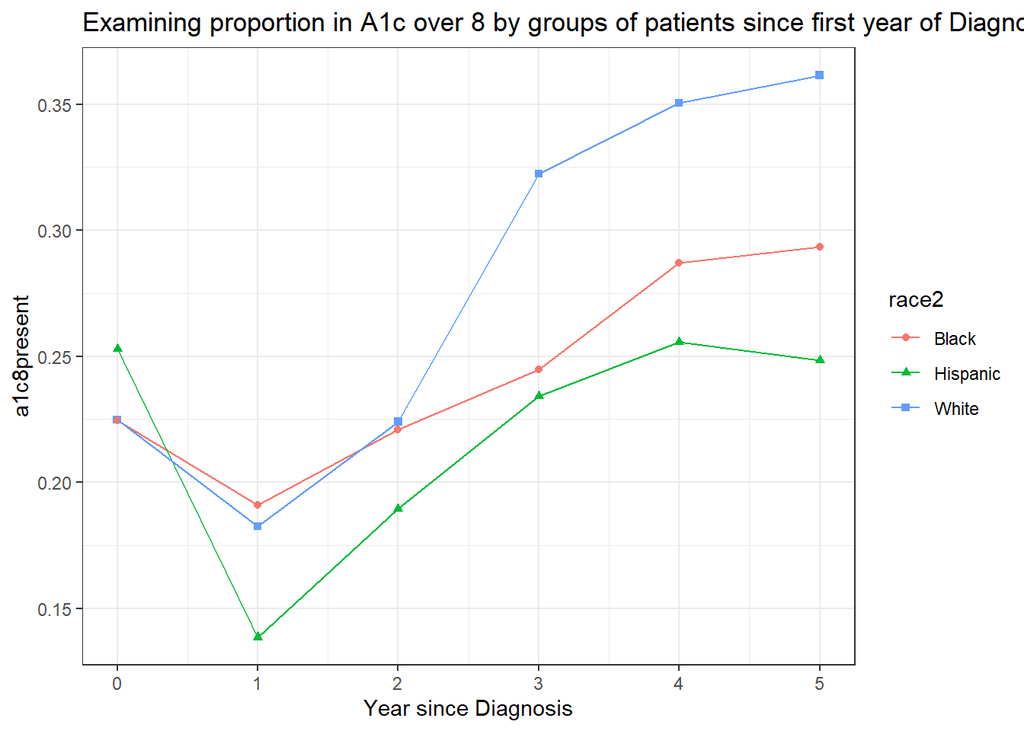

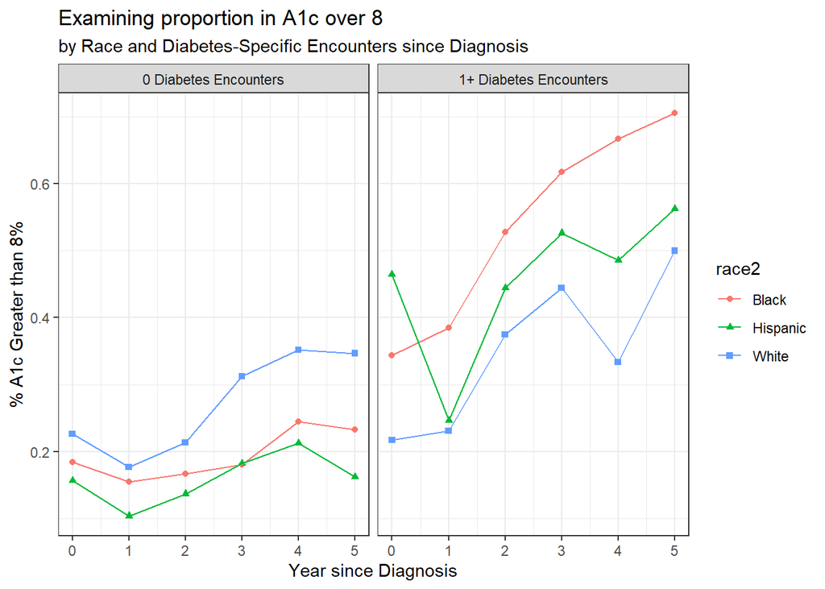

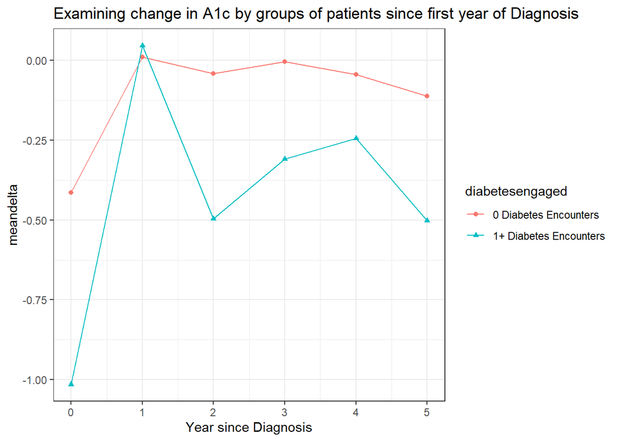

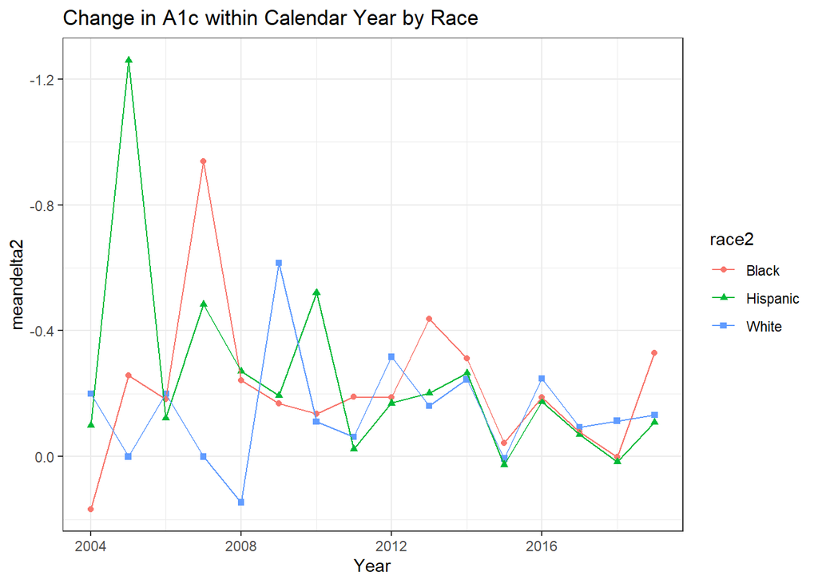

[2 more figures not shown]

# Change Within Calendar Year (CY)

Change in A1c Calculated (Last A1c in CY - First A1c in CY) - Therefore, negative number suggest improvement (i.e. Final A1c=5% - Starting A1c=6% = -1%) during the calendar year

Data frame used is grouped by patients and year of care. Each patient has 5-6 observations. (3440 observations for 652 individuals)

## Assessing collinearity

Collinearity for model Change in Year A1c ~ Diabetes Engagement + Avg BMI + First Recorded A1c + Age at Dx + Total Office Visits + Upstate Location + Utilizing Medicaid

```
##
## Call:
## omcdiag(mod = .)
##
##
## Overall Multicollinearity Diagnostics
##
##                        MC Results detection
## Determinant |X'X|:         0.4374         0
## Farrar Chi-Square:      2825.7903         1
## Red Indicator:             0.1221         0
## Sum of Lambda Inverse:    12.1508         0
## Theil's Method:            1.0516         1
## Condition Number:         46.0275         1
##
## 1 --> COLLINEARITY is detected by the test
## 0 --> COLLINEARITY is not detected by the test
```

```
##
## Call:
## imcdiag(mod = .)
##
##
## All Individual Multicollinearity Diagnostics Result
##
##                                          VIF    TOL       Wi       Fi Leamer
## diabetesengaged1+ Diabetes Encounters 1.0625 0.9411  23.7087  26.6801 0.9701
## avgbmi                                1.0036 0.9964   1.3583   1.5286 0.9982
## firstevera1c                          1.0494 0.9529  18.7275  21.0746 0.9762
## firstage                              1.1184 0.8941  44.8969  50.5238 0.9456
## totalofficevisits                     1.0617 0.9419  23.4051  26.3385 0.9705
## upstate                               1.0753 0.9300  28.5291  32.1047 0.9644
## evermedicaid                          1.0943 0.9138  35.7675  40.2502 0.9559
## sexMale                               1.0428 0.9590  16.2223  18.2555 0.9793
## avgsys                                1.8383 0.5440 317.7946 357.6237 0.7376
## avgdias                               1.8045 0.5542 304.9939 343.2187 0.7444
##                                         CVIF Klein   IND1   IND2
## diabetesengaged1+ Diabetes Encounters 1.0717     1 0.0025 0.4288
## avgbmi                                1.0122     0 0.0026 0.0260
## firstevera1c                          1.0585     1 0.0025 0.3429
## firstage                              1.1281     1 0.0024 0.7714
## totalofficevisits                     1.0709     1 0.0025 0.4236
## upstate                               1.0845     1 0.0025 0.5099
## evermedicaid                          1.1038     1 0.0024 0.6281
## sexMale                               1.0518     1 0.0025 0.2990
## avgsys                                1.8541     1 0.0014 3.3222
## avgdias                               1.8201     1 0.0015 3.2481
##
## 1 --> COLLINEARITY is detected by the test
## 0 --> COLLINEARITY is not detected by the test
##
## avgbmi , firstage , upstate , evermedicaid , avgsys , avgdias , coefficient(s) are non-significant may be due to multicollinearity
##
## R-square of y on all x: 0.0357
##
## * use method argument to check which regressors may be the reason of collinearity
## ===================================
```

## Fixed Effect Models CY

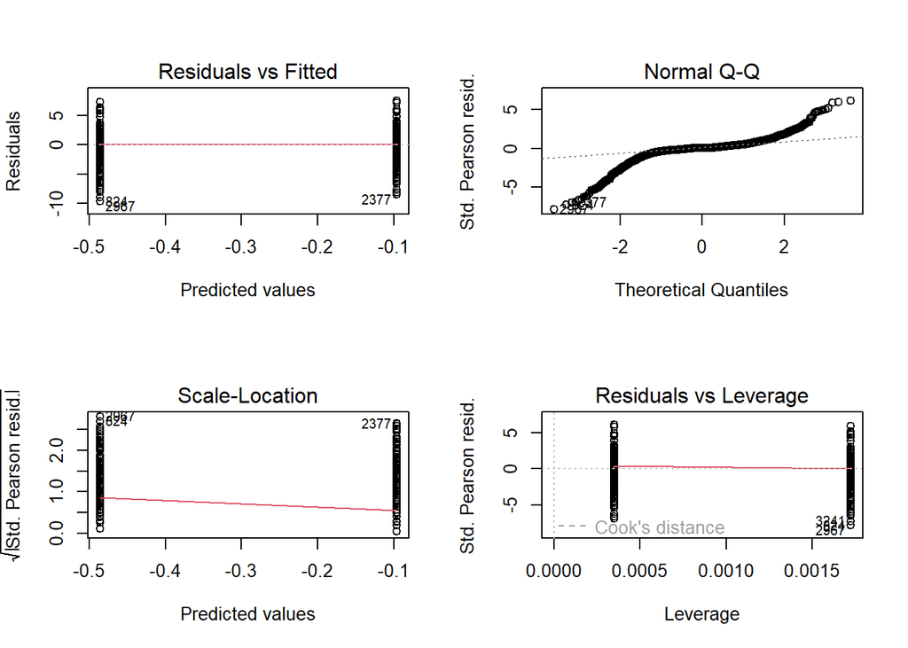

```
##                       GVIF Df GVIF^(1/(2*Df))
## diabetesengaged   1.067929  1        1.033406
## race2             2.312157  2        1.233117
## avgbmi            1.003609  1        1.001803
## firstevera1c      1.049915  1        1.024654
## firstage          1.123985  1        1.060181
## totalofficevisits 1.072605  1        1.035666
## upstate           2.254834  1        1.501610
## sex               1.049068  1        1.024240
## evermedicaid      1.100351  1        1.048976
## avgsys            1.842155  1        1.357260
## avgdias           1.811059  1        1.345756
```

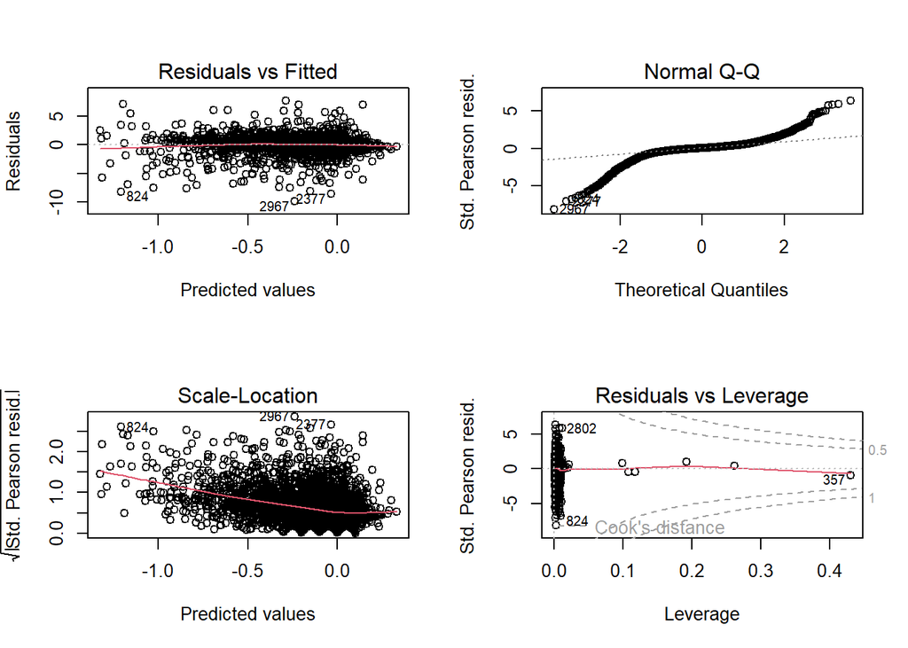

Tbl 2 Regression for engagement in diabetes specific care on change in year A1c stratified by race adjusted for covariates

|  | Unadj | Adj with race | Adj with race interaction | Adj, White | Adj, Black | Adj, Hispanic |
| --- | --- | --- | --- | --- | --- | --- |
| (Intercept) | −0.096 | −0.062 | 0.095 | −0.369 | −0.431 | 0.414 |
|  | [−0.141, −0.051] | [−0.610, 0.486] | [−0.450, 0.640] | [−1.705, 0.967] | [−1.319, 0.457] | [−0.434, 1.261] |
|  | p=<0.001 | p=0.825 | p=0.732 | p=0.588 | p=0.342 | p=0.339 |
| diabetesengaged1+ Diabetes Encounters | −0.390 | −0.325 | −0.462 | −0.240 | −0.273 | −0.389 |
|  | [−0.499, −0.281] | [−0.437, −0.212] | [−0.710, −0.215] | [−0.528, 0.049] | [−0.470, −0.076] | [−0.545, −0.234] |
|  | p=<0.001 | p=<0.001 | p=<0.001 | p=0.103 | p=0.007 | p=<0.001 |
| race2Hispanic |  | 0.080 |  |  |  |  |
|  |  | [−0.012, 0.173] |  |  |  |  |
|  |  | p=0.089 |  |  |  |  |
| race2White |  | 0.012 |  |  |  |  |
|  |  | [−0.145, 0.169] |  |  |  |  |
|  |  | p=0.883 |  |  |  |  |
| avgbmi |  | 0.000 | 0.000 | 0.003 | 0.000 | 0.000 |
|  |  | [0.000, 0.000] | [0.000, 0.000] | [−0.007, 0.013] | [0.000, 0.000] | [0.000, 0.000] |
|  |  | p=0.758 | p=0.754 | p=0.542 | p=0.841 | p=0.742 |
| firstevera1c |  | −0.092 | −0.093 | −0.119 | −0.069 | −0.104 |
|  |  | [−0.117, −0.067] | [−0.118, −0.068] | [−0.177, −0.060] | [−0.110, −0.027] | [−0.142, −0.065] |
|  |  | p=<0.001 | p=<0.001 | p=<0.001 | p=0.001 | p=<0.001 |
| firstage |  | −0.001 | −0.001 | −0.001 | 0.003 | −0.004 |
|  |  | [−0.006, 0.004] | [−0.006, 0.004] | [−0.011, 0.008] | [−0.006, 0.012] | [−0.011, 0.004] |
|  |  | p=0.680 | p=0.649 | p=0.805 | p=0.490 | p=0.345 |
| totalofficevisits |  | −0.008 | −0.008 | 0.008 | −0.011 | −0.018 |
|  |  | [−0.015, −0.001] | [−0.015, −0.001] | [−0.007, 0.023] | [−0.021, 0.000] | [−0.032, −0.003] |
|  |  | p=0.025 | p=0.023 | p=0.323 | p=0.042 | p=0.015 |
| upstate |  | 0.001 | −0.019 | −0.064 | 0.029 | −0.029 |
|  |  | [−0.141, 0.143] | [−0.118, 0.079] | [−0.330, 0.203] | [−0.204, 0.263] | [−0.279, 0.221] |
|  |  | p=0.992 | p=0.699 | p=0.640 | p=0.806 | p=0.821 |
| sexMale |  | −0.097 | −0.099 | −0.131 | −0.060 | −0.096 |
|  |  | [−0.183, −0.010] | [−0.185, −0.013] | [−0.312, 0.049] | [−0.208, 0.087] | [−0.233, 0.041] |
|  |  | p=0.028 | p=0.024 | p=0.153 | p=0.423 | p=0.168 |
| evermedicaid |  | 0.016 | 0.017 | −0.031 | −0.022 | 0.046 |
|  |  | [−0.069, 0.102] | [−0.068, 0.102] | [−0.230, 0.168] | [−0.167, 0.122] | [−0.080, 0.173] |
|  |  | p=0.705 | p=0.697 | p=0.763 | p=0.761 | p=0.472 |
| avgsys |  | 0.004 | 0.004 | 0.005 | 0.002 | 0.005 |
|  |  | [0.000, 0.008] | [0.000, 0.008] | [−0.003, 0.014] | [−0.005, 0.008] | [−0.001, 0.012] |
|  |  | p=0.077 | p=0.076 | p=0.227 | p=0.649 | p=0.125 |
| avgdias |  | 0.003 | 0.003 | 0.005 | 0.007 | −0.001 |
|  |  | [−0.004, 0.010] | [−0.004, 0.010] | [−0.010, 0.019] | [−0.004, 0.018] | [−0.011, 0.010] |
|  |  | p=0.375 | p=0.383 | p=0.534 | p=0.241 | p=0.878 |
| race3 |  |  | −0.053 |  |  |  |
|  |  |  | [−0.104, −0.002] |  |  |  |
|  |  |  | p=0.040 |  |  |  |
| diabetesengaged1+ Diabetes Encounters × race3 |  |  | 0.074 |  |  |  |
|  |  |  | [−0.044, 0.192] |  |  |  |
|  |  |  | p=0.220 |  |  |  |

Tbl 3 Logistic Regression for engagement in diabetes specific care on reduction in A1c in the Calendar Year

|  | Unadj | Adj with race | Adj with race interaction | Adj White | Adj Black | Adj Hispanic |
| --- | --- | --- | --- | --- | --- | --- |
| (Intercept) | 0.717 | 1.661 | 1.568 | 2.260 | 3.800 | 0.791 |
|  | [0.665, 0.772] | [0.658, 4.201] | [0.624, 3.949] | [0.202, 25.444] | [0.923, 15.800] | [0.181, 3.462] |
|  | p=<0.001 | p=0.283 | p=0.339 | p=0.508 | p=0.065 | p=0.756 |
| diabetesengaged1+ Diabetes Encounters | 1.868 | 1.712 | 1.533 | 1.713 | 1.867 | 1.605 |
|  | [1.560, 2.239] | [1.419, 2.067] | [1.013, 2.324] | [1.024, 2.888] | [1.366, 2.560] | [1.229, 2.101] |
|  | p=<0.001 | p=<0.001 | p=0.044 | p=0.041 | p=<0.001 | p=<0.001 |
| race2Hispanic |  | 0.938 |  |  |  |  |
|  |  | [0.802, 1.096] |  |  |  |  |
|  |  | p=0.418 |  |  |  |  |
| race2White |  | 1.127 |  |  |  |  |
|  |  | [0.864, 1.473] |  |  |  |  |
|  |  | p=0.379 |  |  |  |  |
| avgbmi |  | 1.000 | 1.000 | 0.984 | 1.000 | 1.000 |
|  |  | [1.000, 1.000] | [1.000, 1.000] | [0.966, 1.002] | [1.000, 1.001] | [0.999, 1.001] |
|  |  | p=0.898 | p=0.897 | p=0.086 | p=0.678 | p=0.768 |
| firstevera1c |  | 1.029 | 1.028 | 1.111 | 0.990 | 1.031 |
|  |  | [0.987, 1.074] | [0.986, 1.073] | [1.001, 1.237] | [0.926, 1.058] | [0.964, 1.103] |
|  |  | p=0.180 | p=0.192 | p=0.049 | p=0.778 | p=0.368 |
| firstage |  | 1.004 | 1.004 | 1.007 | 0.993 | 1.009 |
|  |  | [0.996, 1.013] | [0.996, 1.013] | [0.990, 1.024] | [0.979, 1.007] | [0.997, 1.022] |
|  |  | p=0.286 | p=0.276 | p=0.448 | p=0.301 | p=0.152 |
| totalofficevisits |  | 1.027 | 1.027 | 1.019 | 1.026 | 1.043 |
|  |  | [1.014, 1.041] | [1.014, 1.041] | [0.992, 1.048] | [1.008, 1.046] | [1.017, 1.070] |
|  |  | p=<0.001 | p=<0.001 | p=0.175 | p=0.007 | p=0.001 |
| upstate |  | 0.751 | 0.833 | 0.878 | 0.611 | 0.911 |
|  |  | [0.588, 0.957] | [0.705, 0.984] | [0.544, 1.422] | [0.413, 0.894] | [0.584, 1.406] |
|  |  | p=0.021 | p=0.032 | p=0.594 | p=0.012 | p=0.676 |
| evermedicaid |  | 1.107 | 1.100 | 1.026 | 1.155 | 1.140 |
|  |  | [0.959, 1.279] | [0.953, 1.270] | [0.714, 1.473] | [0.918, 1.452] | [0.914, 1.420] |
|  |  | p=0.165 | p=0.191 | p=0.888 | p=0.219 | p=0.245 |
| sexMale |  | 1.126 | 1.132 | 1.179 | 1.166 | 1.030 |
|  |  | [0.974, 1.302] | [0.980, 1.309] | [0.851, 1.634] | [0.923, 1.474] | [0.812, 1.308] |
|  |  | p=0.109 | p=0.092 | p=0.323 | p=0.198 | p=0.805 |
| avgsys |  | 0.997 | 0.996 | 0.995 | 0.999 | 0.997 |
|  |  | [0.990, 1.003] | [0.990, 1.003] | [0.980, 1.011] | [0.988, 1.009] | [0.986, 1.008] |
|  |  | p=0.322 | p=0.313 | p=0.579 | p=0.791 | p=0.565 |
| avgdias |  | 0.987 | 0.987 | 0.985 | 0.984 | 0.991 |
|  |  | [0.976, 0.998] | [0.976, 0.998] | [0.959, 1.012] | [0.967, 1.002] | [0.973, 1.010] |
|  |  | p=0.026 | p=0.026 | p=0.272 | p=0.074 | p=0.346 |
| race3 |  |  | 1.020 |  |  |  |
|  |  |  | [0.937, 1.112] |  |  |  |
|  |  |  | p=0.643 |  |  |  |
| diabetesengaged1+ Diabetes Encounters × race3 |  |  | 1.060 |  |  |  |
|  |  |  | [0.869, 1.294] |  |  |  |
|  |  |  | p=0.565 |  |  |  |

Patients had greater odds of seing a reduction of A1c in the calendar year if they saw a diabetes care navigator or educator

## Mixed Effects for CY

### ICC Calculation (CY)

```
## [1] 4.950016e-09
```

```
## [1] 4.921659e-09
```

### Mixed Effect Models

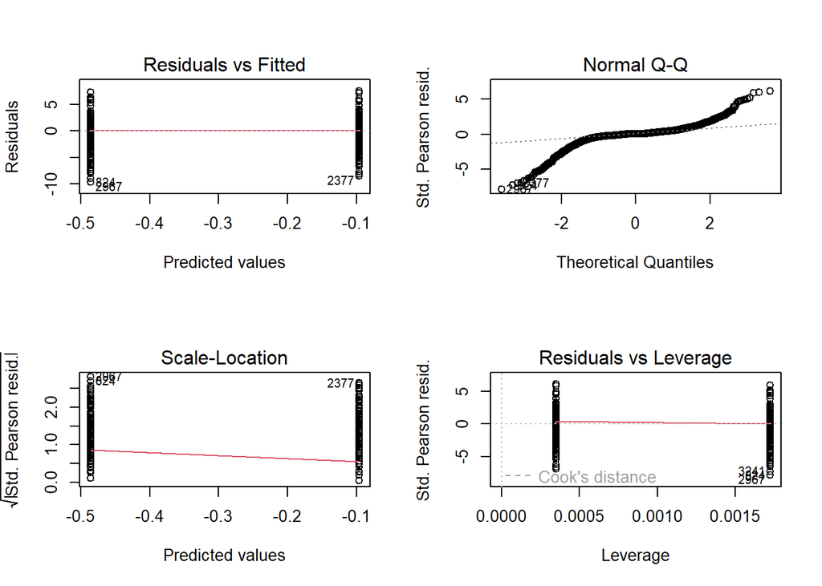

```
##                       GVIF Df GVIF^(1/(2*Df))
## diabetesengaged   1.067929  1        1.033406
## race2             2.312157  2        1.233117
## avgbmi            1.003609  1        1.001803
## firstevera1c      1.049915  1        1.024654
## firstage          1.123985  1        1.060181
## totalofficevisits 1.072605  1        1.035666
## upstate           2.254834  1        1.501610
## sex               1.049068  1        1.024240
## evermedicaid      1.100351  1        1.048976
## avgsys            1.842155  1        1.357260
## avgdias           1.811059  1        1.345756
```

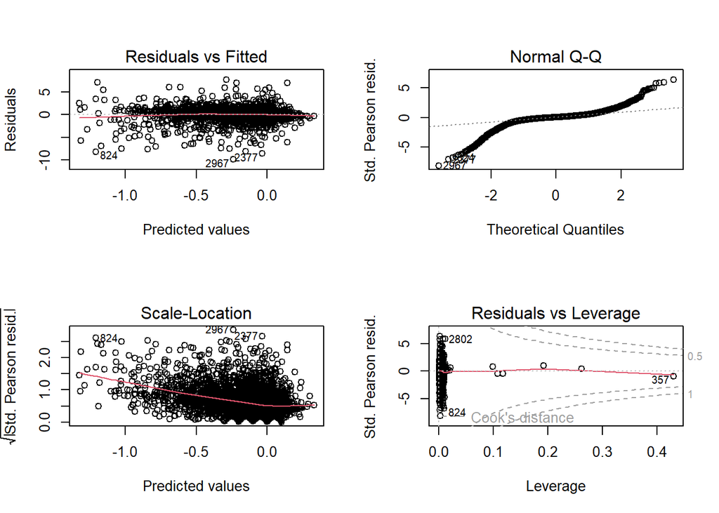

Tbl 4 Mixed Effect regression for engagement in diabetes specific care on change in year A1c stratified by race

|  | Unadjusted | Adj with race | Adj with interaction | Adjusted, White | Adjusted, Black | Adjusted, Hispanic |
| --- | --- | --- | --- | --- | --- | --- |
| (Intercept) | −0.096 | −0.023 | 0.132 | −0.209 | −0.457 | 0.510 |
|  | [−0.141, −0.051] | [−0.569, 0.522] | [−0.410, 0.675] | [−1.492, 1.074] | [−1.341, 0.428] | [−0.324, 1.345] |
|  | p=<0.001 | p=0.933 | p=0.632 | p=0.749 | p=0.311 | p=0.230 |
| diabetesengaged1+ Diabetes Encounters | −0.390 | −0.324 | −0.449 | −0.251 | −0.279 | −0.379 |
|  | [−0.499, −0.281] | [−0.435, −0.212] | [−0.696, −0.202] | [−0.538, 0.037] | [−0.475, −0.083] | [−0.534, −0.224] |
|  | p=<0.001 | p=<0.001 | p=<0.001 | p=0.087 | p=0.005 | p=<0.001 |
| race2Hispanic |  | 0.082 |  |  |  |  |
|  |  | [−0.011, 0.174] |  |  |  |  |
|  |  | p=0.083 |  |  |  |  |
| race2White |  | 0.000 |  |  |  |  |
|  |  | [−0.157, 0.156] |  |  |  |  |
|  |  | p=0.996 |  |  |  |  |
| firstevera1c |  | −0.095 | −0.096 | −0.121 | −0.069 | −0.110 |
|  |  | [−0.120, −0.070] | [−0.121, −0.071] | [−0.179, −0.063] | [−0.110, −0.027] | [−0.148, −0.072] |
|  |  | p=<0.001 | p=<0.001 | p=<0.001 | p=0.001 | p=<0.001 |
| firstage |  | −0.001 | −0.002 | −0.003 | 0.003 | −0.004 |
|  |  | [−0.006, 0.003] | [−0.006, 0.003] | [−0.012, 0.006] | [−0.006, 0.012] | [−0.011, 0.004] |
|  |  | p=0.563 | p=0.528 | p=0.476 | p=0.518 | p=0.333 |
| totalofficevisits |  | −0.008 | −0.008 | 0.008 | −0.010 | −0.018 |
|  |  | [−0.015, −0.001] | [−0.015, −0.001] | [−0.007, 0.023] | [−0.020, 0.000] | [−0.032, −0.004] |
|  |  | p=0.030 | p=0.027 | p=0.276 | p=0.047 | p=0.012 |
| upstate |  | 0.001 | −0.028 | −0.026 | 0.025 | −0.033 |
|  |  | [−0.141, 0.143] | [−0.126, 0.070] | [−0.289, 0.238] | [−0.209, 0.258] | [−0.284, 0.218] |
|  |  | p=0.989 | p=0.573 | p=0.848 | p=0.836 | p=0.797 |
| evermedicaid |  | 0.024 | 0.025 | −0.006 | −0.020 | 0.058 |
|  |  | [−0.061, 0.109] | [−0.059, 0.110] | [−0.201, 0.188] | [−0.164, 0.123] | [−0.067, 0.184] |
|  |  | p=0.577 | p=0.556 | p=0.949 | p=0.780 | p=0.361 |
| avgsys |  | 0.004 | 0.004 | 0.006 | 0.002 | 0.004 |
|  |  | [−0.001, 0.008] | [0.000, 0.008] | [−0.003, 0.015] | [−0.005, 0.008] | [−0.002, 0.011] |
|  |  | p=0.087 | p=0.085 | p=0.170 | p=0.630 | p=0.172 |
| avgdias |  | 0.003 | 0.003 | 0.003 | 0.007 | −0.001 |
|  |  | [−0.004, 0.009] | [−0.004, 0.009] | [−0.011, 0.018] | [−0.004, 0.018] | [−0.012, 0.010] |
|  |  | p=0.410 | p=0.420 | p=0.648 | p=0.237 | p=0.864 |
| race3 |  |  | −0.053 |  |  |  |
|  |  |  | [−0.104, −0.002] |  |  |  |
|  |  |  | p=0.043 |  |  |  |
| diabetesengaged1+ Diabetes Encounters × race3 |  |  | 0.067 |  |  |  |
|  |  |  | [−0.051, 0.185] |  |  |  |
|  |  |  | p=0.265 |  |  |  |
| SD (Intercept newid) | 0.000 | 0.000 | 0.000 | 0.000 | 0.000 | 0.000 |
| SD (Observations) | 1.222 | 1.211 | 1.211 | 1.137 | 1.288 | 1.173 |

Tbl 5 Mixed Effects Logistic Regression for engagement in diabetes specific care on reduction in yearly A1c

|  | Unadjusted | Adj with race | Adj with race interaction | Adj, White | Adj, Black | Adj, Hispanic |
| --- | --- | --- | --- | --- | --- | --- |
| (Intercept) | 0.717 | 1.643 | 1.541 | 1.254 | 3.707 | 0.801 |
|  | [0.665, 0.772] | [0.651, 4.145] | [0.614, 3.870] | [0.122, 12.888] | [0.900, 15.280] | [0.183, 3.500] |
|  | p=<0.001 | p=0.293 | p=0.357 | p=0.849 | p=0.070 | p=0.768 |
| diabetesengaged1+ Diabetes Encounters | 1.868 | 1.697 | 1.514 | 1.702 | 1.854 | 1.590 |
|  | [1.559, 2.237] | [1.407, 2.048] | [1.001, 2.291] | [1.017, 2.848] | [1.355, 2.536] | [1.217, 2.077] |
|  | p=<0.001 | p=<0.001 | p=0.050 | p=0.043 | p=<0.001 | p=<0.001 |
| race2Hispanic |  | 0.933 |  |  |  |  |
|  |  | [0.799, 1.090] |  |  |  |  |
|  |  | p=0.383 |  |  |  |  |
| race2White |  | 1.130 |  |  |  |  |
|  |  | [0.866, 1.474] |  |  |  |  |
|  |  | p=0.370 |  |  |  |  |
| firstevera1c |  | 1.029 | 1.029 | 1.125 | 0.990 | 1.032 |
|  |  | [0.987, 1.074] | [0.986, 1.073] | [1.014, 1.248] | [0.926, 1.058] | [0.965, 1.103] |
|  |  | p=0.179 | p=0.191 | p=0.026 | p=0.762 | p=0.357 |
| firstage |  | 1.004 | 1.005 | 1.010 | 0.993 | 1.009 |
|  |  | [0.996, 1.013] | [0.996, 1.013] | [0.994, 1.027] | [0.979, 1.007] | [0.997, 1.022] |
|  |  | p=0.280 | p=0.270 | p=0.222 | p=0.296 | p=0.151 |
| totalofficevisits |  | 1.027 | 1.027 | 1.018 | 1.026 | 1.043 |
|  |  | [1.014, 1.040] | [1.014, 1.040] | [0.991, 1.046] | [1.007, 1.045] | [1.017, 1.069] |
|  |  | p=<0.001 | p=<0.001 | p=0.187 | p=0.007 | p=0.001 |
| upstate |  | 0.751 | 0.835 | 0.839 | 0.608 | 0.910 |
|  |  | [0.589, 0.957] | [0.707, 0.986] | [0.522, 1.348] | [0.414, 0.894] | [0.587, 1.410] |
|  |  | p=0.021 | p=0.034 | p=0.467 | p=0.011 | p=0.673 |
| sexMale |  | 1.120 | 1.126 | 1.178 | 1.156 | 1.028 |
|  |  | [0.969, 1.294] | [0.975, 1.301] | [0.854, 1.626] | [0.915, 1.461] | [0.811, 1.303] |
|  |  | p=0.126 | p=0.107 | p=0.318 | p=0.223 | p=0.819 |
| evermedicaid |  | 1.110 | 1.103 | 0.967 | 1.168 | 1.137 |
|  |  | [0.962, 1.281] | [0.956, 1.272] | [0.678, 1.380] | [0.930, 1.468] | [0.913, 1.416] |
|  |  | p=0.154 | p=0.180 | p=0.854 | p=0.182 | p=0.252 |
| avgsys |  | 0.997 | 0.996 | 0.994 | 0.999 | 0.997 |
|  |  | [0.990, 1.003] | [0.990, 1.003] | [0.978, 1.010] | [0.988, 1.009] | [0.985, 1.008] |
|  |  | p=0.317 | p=0.307 | p=0.440 | p=0.809 | p=0.541 |
| avgdias |  | 0.987 | 0.987 | 0.985 | 0.984 | 0.991 |
|  |  | [0.976, 0.999] | [0.976, 0.999] | [0.960, 1.011] | [0.967, 1.002] | [0.973, 1.010] |
|  |  | p=0.028 | p=0.029 | p=0.258 | p=0.079 | p=0.348 |
| race3 |  |  | 1.023 |  |  |  |
|  |  |  | [0.939, 1.114] |  |  |  |
|  |  |  | p=0.610 |  |  |  |
| diabetesengaged1+ Diabetes Encounters × race3 |  |  | 1.062 |  |  |  |
|  |  |  | [0.871, 1.296] |  |  |  |
|  |  |  | p=0.551 |  |  |  |
| SD (Intercept newid) | 1.000 | 1.000 | 1.000 | 1.000 | 1.000 | 1.000 |

# Change Between Encounters

This uses the dataframe that includes all observations for all patients with 5 years of continuous care (8817 observations for 652 patients).

Differences in A1c from the previous A1c were created. A binary variable for diabetes encounter was created to identify if the previous encounter was with a diabetes care navigator or educator. Mixed effects with patient id as random effect.

## ICC Calculation

(hba ~ 1 (random=~1|patient_id))

```
## [1] 7.861622e-10
```

## Mixed Effects Models - Encounters

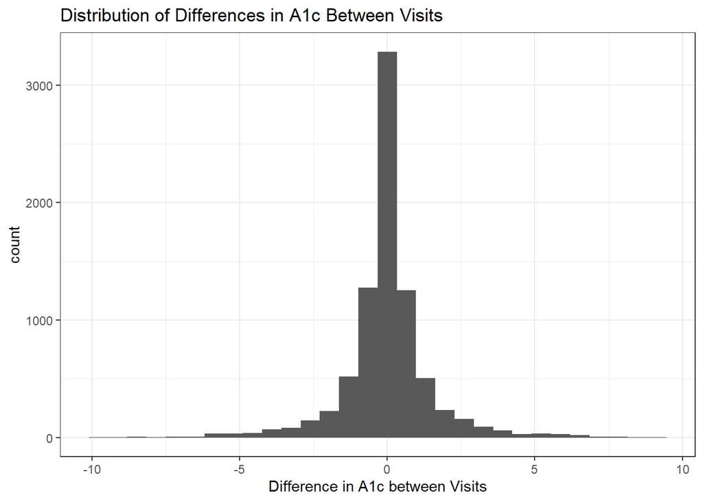

Tbl 6 Mixed Effect regression for engagement in diabetes specific care on change between encounter A1c stratified by race

|  | Unadjusted | Adj with race | Adjusted, White | Adjusted, Black | Adjusted, Hispanic |
| --- | --- | --- | --- | --- | --- |
| (Intercept) | 0.089 | −0.470 | −0.294 | −0.298 | −0.730 |
|  | [0.048, 0.131] | [−0.870, −0.070] | [−1.376, 0.787] | [−0.981, 0.384] | [−1.283, −0.177] |
|  | p=<0.001 | p=0.021 | p=0.593 | p=0.391 | p=0.010 |
| diabetesengaged2 | −0.229 | −0.252 | −0.220 | −0.299 | −0.225 |
|  | [−0.297, −0.161] | [−0.323, −0.182] | [−0.399, −0.041] | [−0.422, −0.176] | [−0.319, −0.130] |
|  | p=<0.001 | p=<0.001 | p=0.016 | p=<0.001 | p=<0.001 |
| race2Hispanic |  | 0.031 |  |  |  |
|  |  | [−0.043, 0.106] |  |  |  |
|  |  | p=0.409 |  |  |  |
| race2White |  | −0.005 |  |  |  |
|  |  | [−0.138, 0.128] |  |  |  |
|  |  | p=0.940 |  |  |  |
| firstevera1c |  | 0.012 | 0.003 | 0.017 | 0.014 |
|  |  | [−0.007, 0.031] | [−0.046, 0.052] | [−0.016, 0.050] | [−0.012, 0.041] |
|  |  | p=0.207 | p=0.902 | p=0.309 | p=0.289 |
| firstage |  | 0.000 | 0.001 | 0.002 | −0.001 |
|  |  | [−0.004, 0.004] | [−0.007, 0.009] | [−0.006, 0.009] | [−0.006, 0.005] |
|  |  | p=0.886 | p=0.816 | p=0.651 | p=0.765 |
| totalofficevisits |  | 0.006 | 0.003 | 0.003 | 0.011 |
|  |  | [0.000, 0.012] | [−0.010, 0.016] | [−0.006, 0.011] | [0.001, 0.021] |
|  |  | p=0.038 | p=0.645 | p=0.547 | p=0.024 |
| upstate |  | −0.031 | −0.034 | −0.009 | −0.056 |
|  |  | [−0.152, 0.090] | [−0.282, 0.214] | [−0.218, 0.200] | [−0.249, 0.136] |
|  |  | p=0.616 | p=0.786 | p=0.933 | p=0.564 |
| medicaiduninsured |  | −0.004 | 0.073 | 0.007 | −0.044 |
|  |  | [−0.073, 0.065] | [−0.107, 0.254] | [−0.113, 0.128] | [−0.138, 0.050] |
|  |  | p=0.903 | p=0.425 | p=0.906 | p=0.357 |
| bp_systolic |  | −0.001 | −0.002 | −0.004 | 0.002 |
|  |  | [−0.004, 0.002] | [−0.008, 0.005] | [−0.008, 0.001] | [−0.001, 0.006] |
|  |  | p=0.489 | p=0.659 | p=0.097 | p=0.221 |
| bp_diastolic |  | 0.005 | 0.001 | 0.008 | 0.003 |
|  |  | [0.001, 0.009] | [−0.010, 0.012] | [0.000, 0.015] | [−0.003, 0.010] |
|  |  | p=0.028 | p=0.868 | p=0.044 | p=0.289 |
| bmi |  | 0.000 | 0.002 | 0.000 | 0.000 |
|  |  | [0.000, 0.000] | [−0.007, 0.011] | [0.000, 0.000] | [0.000, 0.000] |
|  |  | p=0.981 | p=0.680 | p=0.870 | p=0.843 |
| cat_time_dx |  | 0.000 | 0.000 | 0.000 | 0.000 |
|  |  | [0.000, 0.000] | [0.000, 0.001] | [0.000, 0.000] | [0.000, 0.000] |
|  |  | p=<0.001 | p=<0.001 | p=0.145 | p=<0.001 |
| SD (Intercept newid) | 0.000 | 0.000 | 0.000 | 0.000 | 0.000 |
| SD (Observations) | 1.519 | 1.518 | 1.560 | 1.655 | 1.355 |

Tbl 7 Mixed Effects Logistic Regression for engagement in diabetes specific care between reduction encounter A1c

|  | Unadjusted | Adj with race | Adj, White | Adj, Black | Adj, Hispanic |
| --- | --- | --- | --- | --- | --- |
| (Intercept) | 0.820 | 1.538 | 2.004 | 1.659 | 1.474 |
|  | [0.776, 0.866] | [0.905, 2.614] | [0.495, 8.110] | [0.723, 3.805] | [0.648, 3.350] |
|  | p=<0.001 | p=0.111 | p=0.330 | p=0.232 | p=0.354 |
| diabetesengaged2 | 1.200 | 1.210 | 1.214 | 1.291 | 1.136 |
|  | [1.097, 1.313] | [1.103, 1.328] | [0.963, 1.531] | [1.112, 1.499] | [0.988, 1.306] |
|  | p=<0.001 | p=<0.001 | p=0.101 | p=<0.001 | p=0.074 |
| race2Hispanic |  | 1.008 |  |  |  |
|  |  | [0.913, 1.112] |  |  |  |
|  |  | p=0.882 |  |  |  |
| race2White |  | 1.061 |  |  |  |
|  |  | [0.890, 1.264] |  |  |  |
|  |  | p=0.511 |  |  |  |
| firstevera1c |  | 1.024 | 1.023 | 1.031 | 1.014 |
|  |  | [0.999, 1.050] | [0.961, 1.089] | [0.991, 1.074] | [0.975, 1.055] |
|  |  | p=0.064 | p=0.482 | p=0.132 | p=0.478 |
| firstage |  | 0.996 | 0.995 | 0.995 | 0.998 |
|  |  | [0.991, 1.001] | [0.984, 1.005] | [0.986, 1.004] | [0.990, 1.006] |
|  |  | p=0.168 | p=0.327 | p=0.271 | p=0.567 |
| totalofficevisits |  | 0.992 | 0.988 | 0.995 | 0.990 |
|  |  | [0.984, 0.999] | [0.972, 1.006] | [0.984, 1.005] | [0.976, 1.004] |
|  |  | p=0.028 | p=0.185 | p=0.343 | p=0.175 |
| upstate |  | 1.056 | 1.067 | 1.098 | 1.027 |
|  |  | [0.899, 1.239] | [0.776, 1.467] | [0.853, 1.413] | [0.773, 1.365] |
|  |  | p=0.507 | p=0.689 | p=0.470 | p=0.852 |
| medicaiduninsured |  | 0.970 | 1.043 | 0.928 | 0.979 |
|  |  | [0.885, 1.064] | [0.826, 1.317] | [0.801, 1.074] | [0.852, 1.126] |
|  |  | p=0.520 | p=0.723 | p=0.315 | p=0.770 |
| bp_systolic |  | 1.002 | 1.001 | 1.003 | 1.001 |
|  |  | [0.998, 1.005] | [0.992, 1.010] | [0.998, 1.009] | [0.995, 1.006] |
|  |  | p=0.304 | p=0.782 | p=0.215 | p=0.818 |
| bp_diastolic |  | 0.992 | 0.997 | 0.987 | 0.996 |
|  |  | [0.986, 0.998] | [0.983, 1.011] | [0.978, 0.996] | [0.987, 1.006] |
|  |  | p=0.009 | p=0.638 | p=0.004 | p=0.424 |
| bmi |  | 1.000 | 0.993 | 1.000 | 1.000 |
|  |  | [1.000, 1.000] | [0.982, 1.004] | [1.000, 1.000] | [0.999, 1.000] |
|  |  | p=0.405 | p=0.225 | p=0.661 | p=0.504 |
| cat_time_dx |  | 1.000 | 1.000 | 1.000 | 1.000 |
|  |  | [1.000, 1.000] | [0.999, 1.000] | [1.000, 1.000] | [0.999, 1.000] |
|  |  | p=<0.001 | p=<0.001 | p=0.357 | p=<0.001 |
| SD (Intercept newid) | 1.000 | 1.000 | 1.000 | 1.000 | 1.000 |

# REFERENCES

1. National Diabetes Statistics Report 2020. Centers for Disease Control and Prevention; 2020. https://www.cdc.gov/diabetes/pdfs/data/statistics/national-diabetes-statistics-report.pdf
2. Gregg EW, Li Y, Wang J, et al. Changes in Diabetes-Related Complications in the United States, 1990–2010. N Engl J Med. 2014;370(16):1514-1523.
3. Peek ME, Cargill A, Huang ES. Diabetes health disparities: a systematic review of health care interventions. Med Care Res Rev. 2007;64(5 Suppl):101S - 56S.